# Final Project

Zeyuan Wang

12/12/2020

```r
knitr::opts_chunk$set(warning = FALSE, message = FALSE)
```

Website: https://primolls.github.io/Final%20Project.nb.html

Presentation: https://psu.zoom.us/rec/share/GkBacOAtvDmr2Ht3R4Q6BWUZzQcSfRXFiqnFbN_ow7LuQl5hsjIjpn-ZPez1zBPg.3s8mGOH47gEjyABL

```r
# Load packages and stop words
library(genius)
library(tidyverse)
library(tidytext)
library(rvest)
library(ggplot2)
library(gridExtra)
library(stringr)
```

```r
# Load the original stop words
data("stop_words")
```

```r
# Load additional stop words
additionalStopWords <- read.table("AdditionalStopWords.txt")

# Let the additional stop words have the same structure with stop_words
additionalStopWords <- cbind(additionalStopWords, rep("UNKNOWN", dim(additionalStopWords)[1]))
colnames(additionalStopWords) <- c("word", "lexicon")
```

```r
# update stop words by combine the additional and orginal stop words since they have the same structure now
stop_words <- rbind(stop_words, additionalStopWords)
```

```r
# Load list of songs from Wikipedia
page <- "https://en.wikipedia.org/wiki/Grammy_Award_for_Record_of_the_Year"
tableList <- page %>%
  read_html() %>%
  html_nodes(css = "table")
```

```r
# Extract the 4 tables that contains songs from 1980 to 2019 and store them as songList
songList <- rbind(html_table(tableList[[5]], fill = TRUE),
                  html_table(tableList[[6]], fill = TRUE),
                  html_table(tableList[[7]], fill = TRUE),
                  html_table(tableList[[8]], fill = TRUE))
```

```r
# Remove all NAs in songList
songList <- songList[complete.cases(songList),]
# Rename variable names
colnames(songList) <- c("Year", "Track", "Artist", "Production team")
# eliminate variables that we do not really need
songList <-
  songList %>%
  select(Year, Track, Artist)

# Remove numbers in the square brackets after "year" and transfer variable "year" from string to integer (from character to numeric)
# By breaking a string into individual letters and select the first 4 digits
# as.numeric transfers string to numeric values therefore we can treat year as numbers
for (i in 1:dim(songList)[1]){
  songList[i, 1] <- as.numeric(substr(songList[i,1], 1, 4))
}
```

```r
# create data frame of lyrics of songs from 1980 to 2019
songLyrics <- songList %>%
  add_genius(Artist, Track, type = "lyrics")

# break lyrics from lines to words
verse_words <- songLyrics %>%
  unnest_tokens(word, lyric)

# filter out all 1160 stop words, either filter or anti_join would work
plain_words <- verse_words %>%
  anti_join(stop_words)
```

```r
# create a empty array to store the decade information
decade <- c()
# since the decade is indicated by the number other than the unit digit of the year
# we can divide the year by 10 and round the result down by using floor()
# then multiply the result by 10 to get the correct decade
# i.e. if we divide 1989 by 10 and round it down we get 198, then multiply by 10 we get 1980
for (i in 1:dim(verse_words)[1]){
  decade <- append(decade, 10*floor(as.numeric(verse_words$Year[i])/10))
}
# add decade to the dataframe that contains words before we eliminate stop words
verse_words <- cbind(verse_words, decade)
# use as.factor to make decade a factor variable
verse_words$decade <- as.factor(verse_words$decade)

# create a empty array to store the decade information
decade <- c()
# since the decade is indicated by the number other than the unit digit of the year
# we can divide the year by 10 and round the result down by using floor()
# then multiply the result by 10 to get the correct decade
# i.e. if we divide 1989 by 10 and round it down we get 198, then multiply by 10 we get 1980
for (i in 1:dim(plain_words)[1]){
  decade <- append(decade, 10*floor(as.numeric(plain_words$Year[i])/10))
}
# add decade to the dataframe that contains words after we eliminate stop words
plain_words <- cbind(plain_words, decade)
# use as.factor to make decade a factor variable
plain_words$decade <- as.factor(plain_words$decade)
```

# Graph 1

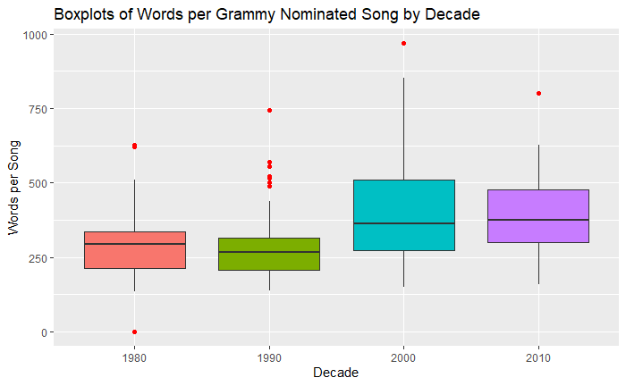

```r
verse_words %>% # identify the dataframe we are going to work with
  group_by(Track) %>% # group by Track(song name) for further counting purpose
  summarise(yearlyTotalWords = n(), decade) %>% # summarise group information
                                                # and select group name, new variable for counting, and decade
  slice(1) %>% # only keep the first row inside each group since members
               # in each group(Track) have identical value for total words
  ggplot() + # create ggplot to graph
  aes(x = decade, y = yearlyTotalWords, fill = decade) + # indicate variables for x and y
                                                         # and fill color by decade
  ggtitle("Boxplots of Words per Grammy Nominated Song by Decade") + # add and name title
  xlab("Decade") + # rename x-axis label
  ylab("Words per Song") + # rename y-axis label
  theme(legend.position = "none") + # remove legend
  geom_boxplot(outlier.colour = "red") # graph boxplot, change outlier color to red
```

The amount of words per song per grammy in 1980s and 1990s doesn’t have too much different on over all distribution, but in 1990s the amount of words are more densed and caused the fence for outliers (IQR) narrower. Total words per song per grammy in 2000s and 2010s seems more than the previous two decades, and 2000s has a larger IQR.

# Graph 2

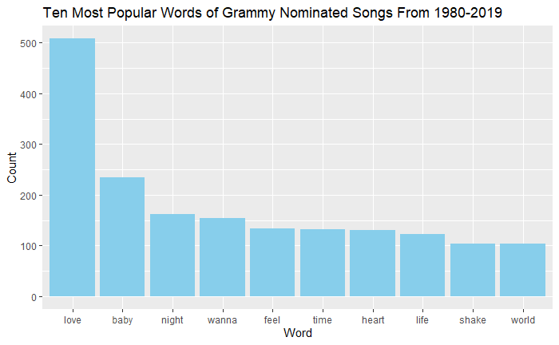

```r
plain_words %>% # identify the dataframe we are going to work with
  count(word, sort = TRUE) %>% # count the amount of words and sort
  top_n(10) %>% # keep only the top 10 values
  arrange(desc(n)) %>% # sort by descending order on n
  ggplot() + # create ggplot to graph
  aes(x = reorder(word, desc(n)), y = n) + # indicate variables for x and y
                                           # and reorder x with descending order by n
  ggtitle ("Ten Most Popular Words of Grammy Nominated Songs From 1980-2019") + # add and name title
  xlab("Word") + # rename x-axis label
  ylab("Count") + # rename y-axis label
  geom_col(fill = "skyblue") # graph bar plot and fill color with skyblue
```

The top ten words in Grammy Nominated Songs from 1980 to 2019 are: love, baby, night, wanna, feel, time, heart, life, shake, world. It seems songs that unburden one’s heart or love songs are easier to win grammy.

# Graph 3

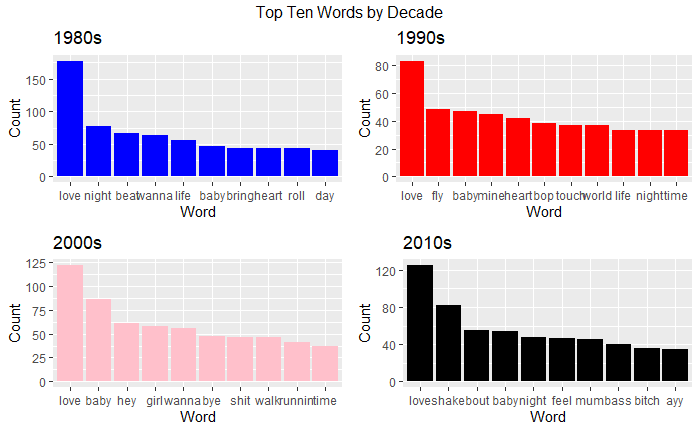

```r
# p(plot) for top 10 words in 1980s
p1 <- plain_words %>% # identify the dataframe we are going to work with
  filter(decade == "1980") %>% # select data in the specified decade
  count(word, sort = TRUE) %>% # count the amount of words and sort
  top_n(10) %>% # keep only the top 10 values
  arrange(desc(n)) %>% # sort by descending order on n
  ggplot() + # create ggplot to graph
  aes(x = reorder(word, desc(n)), y = n) + # indicate variables for x and y
                                           # reorder x with descending order by n
  ggtitle ("1980s") + # add and name title
  xlab("Word") + # rename x-axis label
  ylab("Count") + # rename y-axis label
  geom_col(fill = "blue") # graph bar plot and fill color with blue

# p(plot) for top 10 words in 1990s
p2 <- plain_words %>% # identify the dataframe we are going to work with
  filter(decade == "1990") %>% # select data in the specified decade
  count(word, sort = TRUE) %>% # count the amount of words and sort
  top_n(10) %>% # keep only the top 10 values
  arrange(desc(n)) %>% # sort by descending order on n
  ggplot() + # create ggplot to graph
  aes(x = reorder(word, desc(n)), y = n) + # indicate variables for x and y
                                           # reorder x with descending order by n
  ggtitle ("1990s") + # add and name title
  xlab("Word") + # rename x-axis label
  ylab("Count") + # rename y-axis label
  geom_col(fill = "red") # graph bar plot and fill color with blue

# p(plot) for top 10 words in 2000s
p3 <- plain_words %>% # identify the dataframe we are going to work with
  filter(decade == "2000") %>% # select data in the specified decade
  count(word, sort = TRUE) %>% # count the amount of words and sort
  top_n(10) %>% # keep only the top 10 values
  arrange(desc(n)) %>% # sort by descending order on n
  ggplot() + # create ggplot to graph
  aes(x = reorder(word, desc(n)), y = n) + # indicate variables for x and y
                                           # reorder x with descending order by n
  ggtitle ("2000s") + # add and name title
  xlab("Word") + # rename x-axis label
  ylab("Count") + # rename y-axis label
  geom_col(fill = "pink") # graph bar plot and fill color with blue

# p(plot) for top 10 words in 2010s
p4 <- plain_words %>% # identify the dataframe we are going to work with
  filter(decade == "2010") %>% # select data in the specified decade
  count(word, sort = TRUE) %>% # count the amount of words and sort
  top_n(10) %>% # keep only the top 10 values
  arrange(desc(n)) %>% # sort by descending order on n
  ggplot() + # create ggplot to graph
  aes(x = reorder(word, desc(n)), y = n) + # indicate variables for x and y
                                           # reorder x with descending order by n
  ggtitle ("2010s") + # add and name title
  xlab("Word") + # rename x-axis label
  ylab("Count") + # rename y-axis label
  geom_col(fill = "black") # graph bar plot and fill color with blue

# combine 4 graphs we created above in a 2 by 2 grid and add and name title
grid.arrange(p1, p2, p3, p4, nrow = 2, top = "Top Ten Words by Decade")
```

The top ten words in Grammy Nominated Songs in 1980s are: love, night, beat, wanna, life, baby, bring, heart, roll, day

We can tell that love is always the most popular words, and baby is always popular. But the rest of top ten are always changing. in 1980s and 1990s the words lookes normal, but in 2000s words like “bye”, “shit” appeared in the top ten, indicates people are not reverence for dirty words in lyric as before. In 2010s, ‘bitch’ and ‘ayy’ appeared in the top ten as well, that might because rap is getting more and more popular.

# Graph 4

```r
# recode sentiment from positive/negative to 1/0
# copy everything in sentiments and store in modifiedSentiments
modifiedSentiments <- sentiments

# use for loop to apply certain steps for all elements in modifiedSentiments
for (i in 1:length(modifiedSentiments$sentiment)){
  if (modifiedSentiments[i, 2] == "negative"){ # check if the original value is "negative"
    modifiedSentiments[i, 2] = '0' # if TURE, change it to 0
  }else{
    modifiedSentiments[i, 2] = '1' # otherwise, change it to 1
  }
}
# transfer the type of elements in the sentiment column in modifiedSentiments
# from string to integer (character to numeric)
modifiedSentiments$sentiment = as.numeric(modifiedSentiments$sentiment)
```

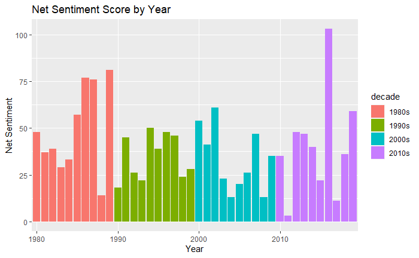

```r
# assign sentiment value for each word
plain_words %>% # identify the dataframe we are going to work with
  left_join(modifiedSentiments, by = "word") %>% # join sentiment information for each words in plain_words
  group_by(Year) %>% # group by year
  mutate(decade = paste(decade, "s", sep = "")) %>% # rename variable 'decade' by adding a 's'
  # summarise group information and select group name, new variable for sum, and decade
  summarise(totalSentiment = sum(sentiment, na.rm = TRUE), decade) %>%
  slice(1) %>% # only keep the first row inside each group
  ggplot() + # create ggplot to graph
  aes(x = Year, y = totalSentiment, fill = decade) + # indicate variables for x and y, and fill color by decade
  scale_x_discrete(breaks = c("1980", "1990", "2000", "2010", "2020")) + # show sepcified marks on the x-axis
  ggtitle ("Net Sentiment Score by Year") + # add and name title
  xlab("Year") + # rename x-axis label
  ylab("Net Sentiment") + # rename y-axis label
  geom_col() # plot bar graph
```